# CreditCardDefault

2025-10-09

# **Credit Risk Model**

## Data Summary/Schema

This model projects the potential for a default payment month based on several demographic factors and payment history. The goal is to ultimately identify trends that can help identify high risk factors in customers earlier. The dataset used is *Default of Credit Card Clients Dataset* on Kaggle. Upon receiving the dataset, I went through and cleaned it to remove any missing or null values and found that there were none of either. I then starting to analyze the data and what types of variables we have:

- **ID**: ID of each client
- **LIMIT_BAL**: Amount of given credit in NT dollars (includes individual and family/supplementary credit
- **SEX**: Gender (1=male, 2=female)
- **EDUCATION**: (1=graduate school, 2=university, 3=high school, 4=others, 5=unknown, 6=unknown)
- **MARRIAGE**: Marital status (0=other/unidentified, 1=married, 2=single, 3=divorce)
- **AGE**: Age in years

Scale for repayment status:

- **-2: No consumption;**
- **-1: Paid in full;**
- **0: The use of revolving credit;**
- **1 = payment delay for one month;**
- **2 = payment delay for two months; . . .;**
- **8 = payment delay for eight months;** **9 = payment delay for nine months and above.**
- **PAY_0**: Repayment status in September, 2005
- **PAY_2**: Repayment status in August, 2005 (scale same as above)
- **PAY_3**: Repayment status in July, 2005 (scale same as above)
- **PAY_4**: Repayment status in June, 2005 (scale same as above)
- **PAY_5**: Repayment status in May, 2005 (scale same as above)
- **PAY_6**: Repayment status in April, 2005 (scale same as above)
- **BILL_AMT1**: Amount of bill statement in September, 2005 (NT dollar)
- **BILL_AMT2**: Amount of bill statement in August, 2005 (NT dollar)
- **BILL_AMT3**: Amount of bill statement in July, 2005 (NT dollar)
- **BILL_AMT4**: Amount of bill statement in June, 2005 (NT dollar)
- **BILL_AMT5**: Amount of bill statement in May, 2005 (NT dollar)
- **BILL_AMT6**: Amount of bill statement in April, 2005 (NT dollar)
- **PAY_AMT1**: Amount of previous payment in September, 2005 (NT dollar)
- **PAY_AMT2**: Amount of previous payment in August, 2005 (NT dollar)
- **PAY_AMT3**: Amount of previous payment in July, 2005 (NT dollar)
- **PAY_AMT4**: Amount of previous payment in June, 2005 (NT dollar)
- **PAY_AMT5**: Amount of previous payment in May, 2005 (NT dollar)
- **PAY_AMT6**: Amount of previous payment in April, 2005 (NT dollar)
- **default.payment.next.month**: Default payment (1=yes, 0=no)

```
##        ID          LIMIT_BAL            SEX          EDUCATION
##  Min.   :    1   Min.   :  10000   Min.   :1.000   Min.   :0.000
##  1st Qu.: 7501   1st Qu.:  50000   1st Qu.:1.000   1st Qu.:1.000
##  Median :15000   Median : 140000   Median :2.000   Median :2.000
##  Mean   :15000   Mean   : 167484   Mean   :1.604   Mean   :1.853
##  3rd Qu.:22500   3rd Qu.: 240000   3rd Qu.:2.000   3rd Qu.:2.000
##  Max.   :30000   Max.   :1000000   Max.   :2.000   Max.   :6.000
##     MARRIAGE          AGE            PAY_0             PAY_2
##  Min.   :0.000   Min.   :21.00   Min.   :-2.0000   Min.   :-2.0000
##  1st Qu.:1.000   1st Qu.:28.00   1st Qu.:-1.0000   1st Qu.:-1.0000
##  Median :2.000   Median :34.00   Median : 0.0000   Median : 0.0000
##  Mean   :1.552   Mean   :35.49   Mean   :-0.0167   Mean   :-0.1338
##  3rd Qu.:2.000   3rd Qu.:41.00   3rd Qu.: 0.0000   3rd Qu.: 0.0000
##  Max.   :3.000   Max.   :79.00   Max.   : 8.0000   Max.   : 8.0000
##      PAY_3             PAY_4             PAY_5             PAY_6
##  Min.   :-2.0000   Min.   :-2.0000   Min.   :-2.0000   Min.   :-2.0000
##  1st Qu.:-1.0000   1st Qu.:-1.0000   1st Qu.:-1.0000   1st Qu.:-1.0000
##  Median : 0.0000   Median : 0.0000   Median : 0.0000   Median : 0.0000
##  Mean   :-0.1662   Mean   :-0.2207   Mean   :-0.2662   Mean   :-0.2911
##  3rd Qu.: 0.0000   3rd Qu.: 0.0000   3rd Qu.: 0.0000   3rd Qu.: 0.0000
##  Max.   : 8.0000   Max.   : 8.0000   Max.   : 8.0000   Max.   : 8.0000
##    BILL_AMT1         BILL_AMT2        BILL_AMT3         BILL_AMT4
##  Min.   :-165580   Min.   :-69777   Min.   :-157264   Min.   :-170000
##  1st Qu.:   3559   1st Qu.:  2985   1st Qu.:   2666   1st Qu.:   2327
##  Median :  22382   Median : 21200   Median :  20088   Median :  19052
##  Mean   :  51223   Mean   : 49179   Mean   :  47013   Mean   :  43263
##  3rd Qu.:  67091   3rd Qu.: 64006   3rd Qu.:  60165   3rd Qu.:  54506
##  Max.   : 964511   Max.   :983931   Max.   :1664089   Max.   : 891586
##    BILL_AMT5        BILL_AMT6          PAY_AMT1         PAY_AMT2
##  Min.   :-81334   Min.   :-339603   Min.   :     0   Min.   :      0
##  1st Qu.:  1763   1st Qu.:   1256   1st Qu.:  1000   1st Qu.:    833
##  Median : 18104   Median :  17071   Median :  2100   Median :   2009
##  Mean   : 40311   Mean   :  38872   Mean   :  5664   Mean   :   5921
##  3rd Qu.: 50190   3rd Qu.:  49198   3rd Qu.:  5006   3rd Qu.:   5000
##  Max.   :927171   Max.   : 961664   Max.   :873552   Max.   :1684259
##     PAY_AMT3         PAY_AMT4         PAY_AMT5           PAY_AMT6
##  Min.   :     0   Min.   :     0   Min.   :     0.0   Min.   :     0.0
##  1st Qu.:   390   1st Qu.:   296   1st Qu.:   252.5   1st Qu.:   117.8
##  Median :  1800   Median :  1500   Median :  1500.0   Median :  1500.0
##  Mean   :  5226   Mean   :  4826   Mean   :  4799.4   Mean   :  5215.5
##  3rd Qu.:  4505   3rd Qu.:  4013   3rd Qu.:  4031.5   3rd Qu.:  4000.0
##  Max.   :896040   Max.   :621000   Max.   :426529.0   Max.   :528666.0
##  default.payment.next.month
##  Min.   :0.0000
##  1st Qu.:0.0000
##  Median :0.0000
##  Mean   :0.2212
##  3rd Qu.:0.0000
##  Max.   :1.0000
```

## Cleaning/Transformation

Of the 25 variables in the data set, I wanted to find the ones that could potentially affect credit risk the most within the model. These will be the best predictors of default payment. To start, I created a variable *def* to indicate that the *default.payment.next.month* variable had a value of 1 and is True. Then I made sure that there weren’t any overly skewed variables. Below are all of the transformations I made:

- Amount of credit given(LIMIT_BAL)

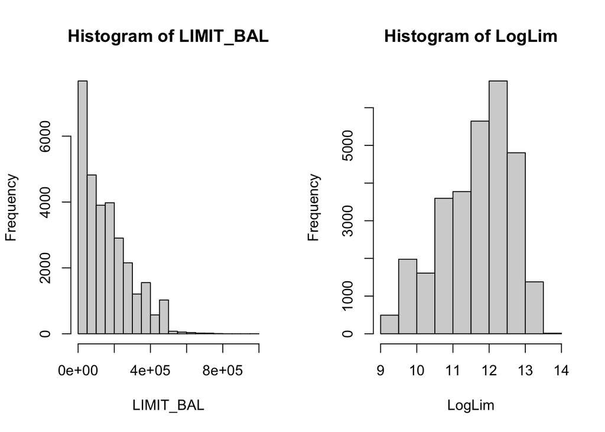

- Age(AGE)

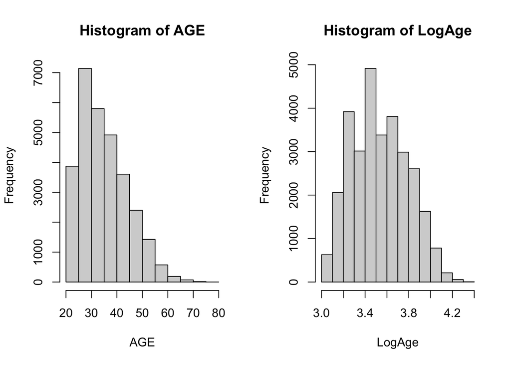

After performing these transformations, I created my first model using all the variables:

```
##
## Call:
## glm(formula = def ~ LogLim + LogAge + factor(SEX) + factor(EDUCATION) +
##     factor(MARRIAGE) + factor(PAY_0) + factor(PAY_2) + factor(PAY_3) +
##     factor(PAY_4) + factor(PAY_5) + factor(PAY_6) + PAY_AMT1 +
##     PAY_AMT2 + PAY_AMT3 + PAY_AMT4 + PAY_AMT5 + PAY_AMT6 + BILL_AMT1 +
##     BILL_AMT2 + BILL_AMT3 + BILL_AMT4 + BILL_AMT5 + BILL_AMT6,
##     family = binomial(link = logit))
##
## Coefficients:
##                      Estimate Std. Error z value Pr(>|z|)
## (Intercept)        -1.169e+01  1.410e+02  -0.083 0.933933
## LogLim             -2.900e-01  2.164e-02 -13.404  < 2e-16 ***
## LogAge              1.373e-01  7.343e-02   1.869 0.061585 .
## factor(SEX)2       -1.187e-01  3.251e-02  -3.650 0.000262 ***
## factor(EDUCATION)1  1.178e+01  1.410e+02   0.084 0.933412
## factor(EDUCATION)2  1.179e+01  1.410e+02   0.084 0.933363
## factor(EDUCATION)3  1.173e+01  1.410e+02   0.083 0.933711
## factor(EDUCATION)4  1.072e+01  1.410e+02   0.076 0.939422
## factor(EDUCATION)5  1.049e+01  1.410e+02   0.074 0.940699
## factor(EDUCATION)6  1.148e+01  1.410e+02   0.081 0.935116
## factor(MARRIAGE)1   1.448e+00  5.213e-01   2.777 0.005484 **
## factor(MARRIAGE)2   1.286e+00  5.215e-01   2.466 0.013677 *
## factor(MARRIAGE)3   1.482e+00  5.402e-01   2.743 0.006094 **
## factor(PAY_0)-1     5.147e-01  1.082e-01   4.755 1.99e-06 ***
## factor(PAY_0)0     -2.315e-01  1.169e-01  -1.981 0.047592 *
## factor(PAY_0)1      8.066e-01  8.462e-02   9.531  < 2e-16 ***
## factor(PAY_0)2      2.048e+00  1.061e-01  19.302  < 2e-16 ***
## factor(PAY_0)3      2.057e+00  1.697e-01  12.118  < 2e-16 ***
## factor(PAY_0)4      1.704e+00  2.994e-01   5.694 1.24e-08 ***
## factor(PAY_0)5      1.441e+00  4.845e-01   2.975 0.002929 **
## factor(PAY_0)6      5.320e-01  8.867e-01   0.600 0.548501
## factor(PAY_0)7      1.741e+00  1.484e+00   1.174 0.240537
## factor(PAY_0)8     -1.231e+01  5.354e+02  -0.023 0.981656
## factor(PAY_2)-1    -2.030e-01  1.138e-01  -1.783 0.074545 .
## factor(PAY_2)0     -9.997e-03  1.391e-01  -0.072 0.942693
## factor(PAY_2)1     -6.881e-01  5.772e-01  -1.192 0.233169
## factor(PAY_2)2     -9.263e-03  1.176e-01  -0.079 0.937199
## factor(PAY_2)3     -1.001e-02  1.800e-01  -0.056 0.955682
## factor(PAY_2)4     -7.864e-01  3.222e-01  -2.441 0.014659 *
```

[output cut: 49 more lines]

```
## BILL_AMT2           2.374e-06  1.416e-06   1.677 0.093577 .
## BILL_AMT3           2.185e-06  1.270e-06   1.720 0.085451 .
## BILL_AMT4          -1.858e-07  1.293e-06  -0.144 0.885699
## BILL_AMT5          -5.253e-07  1.494e-06  -0.352 0.725202
## BILL_AMT6          -1.520e-07  1.182e-06  -0.129 0.897701
## ---
## Signif. codes:  0 '***' 0.001 '**' 0.01 '*' 0.05 '.' 0.1 ' ' 1
##
## (Dispersion parameter for binomial family taken to be 1)
##
##     Null deviance: 31705  on 29999  degrees of freedom
## Residual deviance: 25940  on 29917  degrees of freedom
## AIC: 26106
##
## Number of Fisher Scoring iterations: 12
```

```r
CCD[which(abs(rstandard(m1))>2.0),]
```

```
## # A tibble: 1,171 × 25
##       ID LIMIT_BAL   SEX EDUCATION MARRIAGE   AGE PAY_0 PAY_2 PAY_3 PAY_4 PAY_5
##    <dbl>     <dbl> <dbl>     <dbl>    <dbl> <dbl> <dbl> <dbl> <dbl> <dbl> <dbl>
##  1    24    450000     2         1        1    40    -2    -2    -2    -2    -2
##  2    48    150000     2         5        2    46     0     0    -1     0     0
##  3    61    500000     2         3        1    28     0     0     0     0     0
##  4    79     30000     2         2        2    22     0     0     0     0     0
##  5    83     60000     1         3        2    30     0     0     0     0     0
##  6   104     50000     2         3        2    22     0     0     0     0     0
##  7   113    280000     1         2        1    41     2     2     2     2     2
##  8   128    180000     1         1        1    36     0     0     0     0     0
##  9   147    170000     2         2        2    27     0     0     0     0     0
## 10   209     80000     2         2        2    24     0     0     0     0     0
## # ℹ 1,161 more rows
## # ℹ 14 more variables: PAY_6 <dbl>, BILL_AMT1 <dbl>, BILL_AMT2 <dbl>,
## #   BILL_AMT3 <dbl>, BILL_AMT4 <dbl>, BILL_AMT5 <dbl>, BILL_AMT6 <dbl>,
## #   PAY_AMT1 <dbl>, PAY_AMT2 <dbl>, PAY_AMT3 <dbl>, PAY_AMT4 <dbl>,
## #   PAY_AMT5 <dbl>, PAY_AMT6 <dbl>, default.payment.next.month <dbl>
```

```r
#Identifying high leverage points:
#k=82 x terms
#Cutoff for high leverage:
#3(k+1)/n = 3(83)/30000= 0.0083
#0.0083 is our cutoff point

#Finding high leverage points:
leverages = hatvalues(m1)
CCD[which(leverages>0.0083),]
```

```
## # A tibble: 1,096 × 25
##       ID LIMIT_BAL   SEX EDUCATION MARRIAGE   AGE PAY_0 PAY_2 PAY_3 PAY_4 PAY_5
##    <dbl>     <dbl> <dbl>     <dbl>    <dbl> <dbl> <dbl> <dbl> <dbl> <dbl> <dbl>
##  1    41    360000     1         1        2    33     0     0     0     0     0
##  2    70     20000     1         5        2    22     2     0     0     0     0
##  3   116     30000     1         1        2    24    -1     2     0     0     3
##  4   146     50000     1         1        2    28     0     0     0     0     0
##  5   149     80000     2         2        1    23     1     2     3     2     0
##  6   159    210000     1         3        1    45     2     3     4     4     5
##  7   176    130000     1         3        1    56     1     2     2     2     2
##  8   190     20000     2         2        2    31     1     5     4     4     3
##  9   215    470000     1         2        2    27     2     2     2     2     0
## 10   291    280000     1         1        2    33    -1    -1    -1    -1    -1
## # ℹ 1,086 more rows
## # ℹ 14 more variables: PAY_6 <dbl>, BILL_AMT1 <dbl>, BILL_AMT2 <dbl>,
## #   BILL_AMT3 <dbl>, BILL_AMT4 <dbl>, BILL_AMT5 <dbl>, BILL_AMT6 <dbl>,
## #   PAY_AMT1 <dbl>, PAY_AMT2 <dbl>, PAY_AMT3 <dbl>, PAY_AMT4 <dbl>,
## #   PAY_AMT5 <dbl>, PAY_AMT6 <dbl>, default.payment.next.month <dbl>
```

```r
#Finding points that exceed Cook's Distance:
#Cutoff is F-Critical Value:
#df1 = k + 1 = 83
#df2 = n-(k+1) = 30,000 -(83)=29,917
qf(.95, 83, 29917)
```

```
## [1] 1.268793
```

```r
#Our cutoff for Cook's Distance is 1.268793
CCD[which(cooks.distance(m1)>1.268793),]
```

```
## # A tibble: 4 × 25
##      ID LIMIT_BAL   SEX EDUCATION MARRIAGE   AGE PAY_0 PAY_2 PAY_3 PAY_4 PAY_5
##   <dbl>     <dbl> <dbl>     <dbl>    <dbl> <dbl> <dbl> <dbl> <dbl> <dbl> <dbl>
## 1 11845     30000     2         1        2    24     2     2     6     6     5
## 2 12877     20000     2         3        2    28     1     3     6     5     4
## 3 14615     10000     1         3        2    29     2     2     6     6     6
## 4 25144     30000     1         3        1    56     1     7     6     5     4
## # ℹ 14 more variables: PAY_6 <dbl>, BILL_AMT1 <dbl>, BILL_AMT2 <dbl>,
## #   BILL_AMT3 <dbl>, BILL_AMT4 <dbl>, BILL_AMT5 <dbl>, BILL_AMT6 <dbl>,
## #   PAY_AMT1 <dbl>, PAY_AMT2 <dbl>, PAY_AMT3 <dbl>, PAY_AMT4 <dbl>,
## #   PAY_AMT5 <dbl>, PAY_AMT6 <dbl>, default.payment.next.month <dbl>
```

```r
#These are the points that exceed Cook's Distance
```

```r
#Removing all outliers and high leverage points:
rsta = rstandard(m1)
CCD1 = subset(CCD,leverages>0.0083&rsta<2&rsta>-2&cooks.distance(m1)<1.268793)
CCD2 = na.omit(CCD1, header = T)
attach(CCD2)
```

Then, I recreated our original logistic regression model using the new subset:

```r
#Original Model, cleaned dataset
def= default.payment.next.month==1
LogAge=log(AGE)
LogLim=log(LIMIT_BAL)
m1=glm(def ~ LogLim + LogAge + factor(SEX) + factor(EDUCATION) + factor(MARRIAGE) + factor(PAY_0) + factor(PAY_2) + factor(PAY_3) + factor(PAY_4) + factor(PAY_5) + factor(PAY_6) + PAY_AMT1 + PAY_AMT2 + PAY_AMT3 + PAY_AMT4 + PAY_AMT5 + PAY_AMT6 + BILL_AMT1 + BILL_AMT2 + BILL_AMT3 + BILL_AMT4 + BILL_AMT5 + BILL_AMT6, family = binomial(link = logit))
summary(m1)
```

```
##
## Call:
## glm(formula = def ~ LogLim + LogAge + factor(SEX) + factor(EDUCATION) +
##     factor(MARRIAGE) + factor(PAY_0) + factor(PAY_2) + factor(PAY_3) +
##     factor(PAY_4) + factor(PAY_5) + factor(PAY_6) + PAY_AMT1 +
##     PAY_AMT2 + PAY_AMT3 + PAY_AMT4 + PAY_AMT5 + PAY_AMT6 + BILL_AMT1 +
##     BILL_AMT2 + BILL_AMT3 + BILL_AMT4 + BILL_AMT5 + BILL_AMT6,
##     family = binomial(link = logit))
##
## Coefficients: (3 not defined because of singularities)
##                      Estimate Std. Error z value Pr(>|z|)
## (Intercept)        -1.614e+01  6.153e+02  -0.026 0.979074
## LogLim             -3.465e-01  1.218e-01  -2.846 0.004425 **
## LogAge              1.388e-01  3.435e-01   0.404 0.686101
## factor(SEX)2       -1.349e-01  1.668e-01  -0.809 0.418747
## factor(EDUCATION)1  1.457e+01  6.153e+02   0.024 0.981112
## factor(EDUCATION)2  1.470e+01  6.153e+02   0.024 0.980941
## factor(EDUCATION)3  1.491e+01  6.153e+02   0.024 0.980668
## factor(EDUCATION)4  1.161e+01  6.153e+02   0.019 0.984941
## factor(EDUCATION)5  1.239e+01  6.153e+02   0.020 0.983934
## factor(EDUCATION)6  1.302e+01  6.153e+02   0.021 0.983120
## factor(MARRIAGE)1   3.960e+00  1.093e+00   3.621 0.000293 ***
## factor(MARRIAGE)2   3.622e+00  1.095e+00   3.307 0.000942 ***
## factor(MARRIAGE)3   4.315e+00  1.190e+00   3.627 0.000287 ***
## factor(PAY_0)-1     1.325e+00  1.066e+00   1.243 0.213743
## factor(PAY_0)0     -1.611e+00  1.118e+00  -1.441 0.149721
## factor(PAY_0)1      1.041e+00  1.017e+00   1.024 0.305985
## factor(PAY_0)2      1.860e+00  1.044e+00   1.782 0.074748 .
## factor(PAY_0)3      2.688e+00  1.082e+00   2.484 0.012983 *
## factor(PAY_0)4      2.087e+00  1.080e+00   1.932 0.053415 .
## factor(PAY_0)5      2.023e+00  1.140e+00   1.775 0.075878 .
## factor(PAY_0)6      6.386e-01  1.387e+00   0.460 0.645299
## factor(PAY_0)7      2.180e+00  1.823e+00   1.196 0.231743
## factor(PAY_0)8      3.297e+00  1.467e+00   2.248 0.024573 *
## factor(PAY_2)-1     1.550e-01  9.193e-01   0.169 0.866102
## factor(PAY_2)0      1.885e+00  1.005e+00   1.876 0.060682 .
## factor(PAY_2)1     -1.073e+00  1.006e+00  -1.067 0.286164
## factor(PAY_2)2      8.186e-01  8.923e-01   0.917 0.358922
## factor(PAY_2)3      3.427e-01  9.362e-01   0.366 0.714343
## factor(PAY_2)4     -4.467e-01  9.454e-01  -0.473 0.636557
```

[output cut: 44 more lines]

```
## BILL_AMT2           4.004e-06  2.870e-06   1.395 0.163023
## BILL_AMT3           4.119e-06  2.385e-06   1.727 0.084142 .
## BILL_AMT4          -3.484e-06  2.722e-06  -1.280 0.200527
## BILL_AMT5           1.136e-06  3.080e-06   0.369 0.712233
## BILL_AMT6           2.032e-06  2.427e-06   0.837 0.402436
## ---
## Signif. codes:  0 '***' 0.001 '**' 0.01 '*' 0.05 '.' 0.1 ' ' 1
##
## (Dispersion parameter for binomial family taken to be 1)
##
##     Null deviance: 1450.67  on 1051  degrees of freedom
## Residual deviance:  967.68  on  977  degrees of freedom
## AIC: 1117.7
##
## Number of Fisher Scoring iterations: 15
```